# Hands-on Traning

4/24/2018

## Part I: WRF

## WRF Tutorial

- Next WRF Tutorial
  - Registration is now open. https://www.mmm.ucar.edu/wrf-tutorial-0
    - The next WRF tutorial will be held **July 23-27, 2018 in Boulder, CO**. For this summer session, there will only be a Basic WRF Tutorial, with no additional tutorials the following week.
- Future WRF Tutorials
  - January 2019 and July 2019
- WRF-Hydro Training Workshop
  - June 5 - 8, 2018, sponsored by [CUAHSI](https://www.cuahsi.org/education/training/training-and-workshops/training-workshop-the-community-wrf-hydro-modeling-system-1)
  - **Application deadline has passed.**

## WRF Overview

- Weather Research and Forecasting (**WRF**)
  - Meteorological studies
  - Real-time NWP
  - Idealized simulations
  - Data assimilation
  - Earth system model coupling
  - Model training and education
- WRF Variants
  - **WRF-Hydro**: WRF hydrological modeling system
  - **WRFDA**: WRF Data Assimilation System
  - **WRF-Chem**: WRF atmospheric chemistry model
  - **Polar-WRF** ,**HWRF**, **NU-WRF**

## WRF Components

[figure not shown]

- As shown in the diagram
  - The WRF Preprocessing System (WPS)
  - *WRF-DA*
  - **WRF ARW solver**
  - Post-processing & Visualization tools

## WRF Conponents: WPS

- Lake Champlain `namelist.wps`

```yaml
&share
 wrf_core = 'ARW',
 max_dom = 1,
 start_date = '2011-01-01_00:00:00','2014-11-16_00:00:00'
 end_date   = '2011-01-02_00:00:00','2014-11-17_00:00:00'
 interval_seconds = 10800
 io_form_geogrid = 2,
/

&geogrid
 parent_id         =   1,   1,  2,
 parent_grid_ratio =   1,   4,  3,
 i_parent_start    =   1,  20,  93,
 j_parent_start    =   1,  15,  41,
 e_we              =  201, 101, 331,
 e_sn              =  361, 145, 291,
 geog_data_res     = 'modis_15s','modis_15s','2m',
 dx = 1000,
 dy = 1000,
 map_proj = 'lambert',
 ref_lat   = 44.58 ,
 ref_lon   = -73.2,
 truelat1  =  30.0,
 truelat2  =  60.0,
 stand_lon = -97,
 geog_data_path = '/glade/u/home/wrfhelp/WPS_GEOG'
/

&ungrib
 out_format = 'WPS',
 prefix = 'FILE',
/

&metgrid
 fg_name = 'FILE'
 io_form_metgrid = 2,
/
```

- defining simulation domains
- interpolating terrestrial data to the simulation domain
- degribbing and interpolating meteorological data

[figure not shown]

## WRF Data Flow

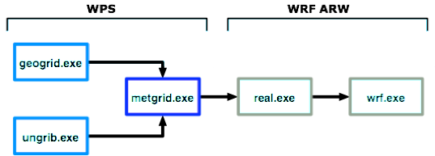

- Executables
- Data Flow

[figure not shown]

## WRF Resource

| WRF Source Code Browser | http://math.ucdenver.edu/~mvejmelka/wrf-browsers/master/ |
| --- | --- |
| WRF User’s Guides online/pdf | http://www2.mmm.ucar.edu/wrf/users/docs/user_guide_V3/contents.html |
| Semi-annual WRF Tutorial (July and January) | http://www2.mmm.ucar.edu/wrf/users/supports/tutorial.html |
| Annual WRF Users Workshop | http://www2.mmm.ucar.edu/wrf/users/supports/workshop.html |
| WRF Forum | http://forum.wrfforum.com/ |

## Part II: WRF-Hydro

## WRF Directory

To show on computer

```yaml
cd ~wrfhelp/PRE_COMPILED_CHEYENNE/WRFV3.7.1_intel_dmpar_large-file
tree
```

## WRF-Hydro Framework

[figure not shown]

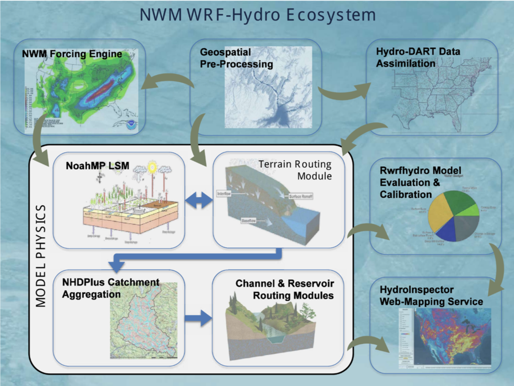

(Courtesy **WRF-Hdyro Training Material**)

## WRF-Hydro Framework

[video not shown]

## WRF-Hydro Dataflow

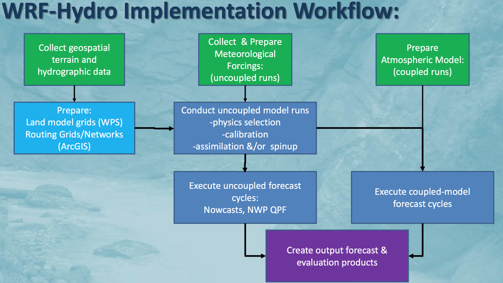

(Courtesy **WRF-Hdyro Training Material**)

## WRF-Hydro Code Framework

To show on computer

```yaml
cd /glade/u/home/cxiao/WORK/WRFHydro5.0/wrf_hydro_community_v5.0.0/
tree
```

## WRF-Hydro training material

https://ral.ucar.edu/projects/wrf_hydro/training-materials

```
Multi-scale Water Cycle Predictions Using the Community WRF-Hydro Modeling System
WRF-Hydro: System Conceptualization
Compiling and Executing WRF-Hydro
WRF-Hydro & NoahMP LSM Physics Overview
WRF-Hydro System: Physics Components
Channel Routing & Lakes and Reservoirs in WRF-Hydro
WRF-Hydro Forcing & Preprocessing Input Data Requirements
Overview of the ArcGIS WRF-Hydro Pre-processing Tool
WRF-Hydro: Coupling with WRF
The WRF-Hydro Modeling System: Implementation & Calibration Approaches
WRF-Hydro Data Assimilation Approaches
WRF-Hydro Calibration Approaches
WRF-Hydro hydro.namelist files with Description of Options
NoahMP namelist.hrldas with a Description of Options
```